# Predicting User Ratings on Yelp

## 3.2 Lasso results

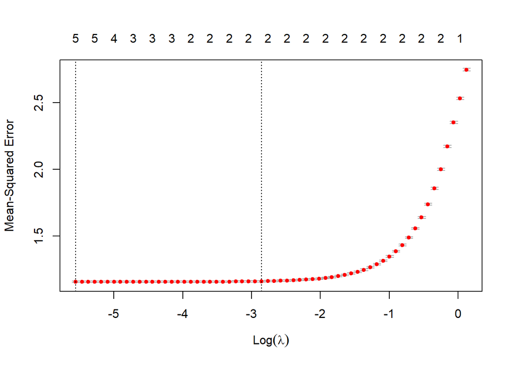

## 3.3 Decision Tree results

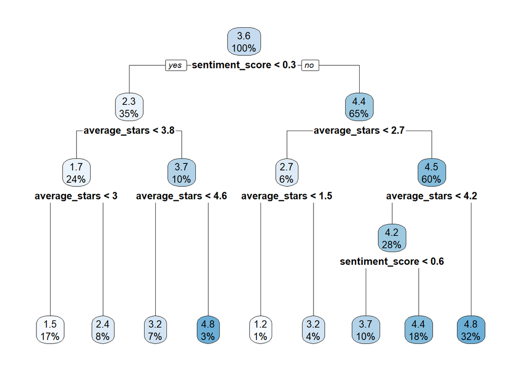

The results from the decision tree shows that the independent variables that gave us the most information was the sentiment score followed by the average user stars, in line with our results from the lasso regression. The root node separates data into sentiment score less than 0.3 or greater than or equal to 0.3. Average star variable is then used for finer distinctions. Our predicted value ranges from 1.2 to 4.8 covering majority of possible entries from 1-5 stars. The percentages show how many data observations fall into each category.